```r
library(readr)
library(tidyselect)
library(tidymodels)
```

```r
library(ggplot2)
library(discrim)
library(recipes)
library(mlbench)
```

# Discriminant Analysis and Support Vector Machines

## Instructions

You will submit an HTML document to Canvas as your final version.

You may work with one other person for this assignment. Make sure both your names are on the HTML document, and you should both upload a copy of the assignment to Canvas.

Your document should show your code chunks/cells as well as any output. Make sure that only relevant output is printed. Do not, for example, print the entire dataset in your final knitted file.

Your document should also be clearly organized, so that it is easy for a reader to find your answers to each question.

There may be a small penalty for submissions that are difficult to read or navigate.

## Dataset: Zoo animals

This week’s dataset contains information about animals commonly found at a zoo. The data contains dummy variables for several features that an animal might have, such as:

Is the animal a predator? Does the animal produce milk? Is the animal aquatic? There is also one quantitative variable, legs stating how many legs the animal has.

Run the following code to read the data:

```r
zoo <- read_csv("https://www.dropbox.com/s/kg89g2y3tp6p9yh/zoo_final.csv?dl=1")
```

## Part One: PCA preprocessing

### Q1: PCA

Below are the results of a PCA transformation of the data, with the non-dummy categorical variables removed removed. This shows the rotations for the first three PCs. Interpret the results - which variables are most important in spreading the observations? What do each of the first three PCs seem to represent?

```r
##                   PC1         PC2         PC3
## hair     -0.105585831  0.38073598 -0.09725382
## feathers  0.041574511 -0.17518616 -0.36315088
## eggs      0.064480975 -0.43910323  0.03568660
## milk     -0.062292761  0.44962528 -0.05531073
## airborne -0.008309226 -0.21363144 -0.38359657
## aquatic   0.094520646 -0.12172374  0.43441572
## predator  0.028764647  0.01215395  0.41586206
## toothed   0.041180336  0.40140542  0.21937528
## backbone  0.077587066  0.22450177 -0.14271590
## breathes -0.080155281  0.11011203 -0.38173733
## venomous -0.002117142 -0.05018278  0.07080822
## fins      0.113910026  0.03025333  0.24792931
## legs     -0.967377908 -0.08115149  0.10446504
## tail      0.074713579  0.18205017 -0.18875383
## domestic -0.015625507  0.03790715 -0.13169846
## catsize  -0.022083876  0.31705241  0.03067264
```

- The PC’s are vectors represent the direction of variation of the data. The variables explain variation captured by each of the PC’s for different features of each of the animal name present in the dataset. For the PC1, the most important features are legs, fins and hair. For PC2, the most important features are milk, eggs and toothed. For PC3, the most important features are aquatic, predator and airborne

### Q2: Choosing PCs

Look at the percent of variance explained by each PC. How many PCs would you choose to include in a model for predicting species from animal features? Why?

```r
##  [1] 0.6288151366 0.1435312995 0.0729556109 0.0391740756 0.0244446038
##  [6] 0.0213281612 0.0149124424 0.0124983870 0.0103489380 0.0096347615
## [11] 0.0080554590 0.0054063100 0.0042702391 0.0030127849 0.0011080962
## [16] 0.0005036944

(0.6288151366 +0.1435312995 +0.0729556109+ 0.0391740756 +0.0244446038)
```

```
## [1] 0.9089207
```

- We would choose the first 5 PC’s to include in a model since that explains 90% of variation in the data.

### Q3: New dataset

Since PCA is a data processing tool, we can instead apply it as part of a step_ function in tidymodels.

The step_pca() addition to your recipe will automatically include the PCA process in your data pipeline.

Adjust the code below to complete this recipe:

```r
zoo_rec <- recipe(Class_Type ~ ., data = zoo) %>%
  step_pca(all_numeric(), threshold = 0.8,
           options = c(center = TRUE))
```

The prep() step is then used to prepare by computing the PCs, and the bake() function is then used to make a new dataframe with the chosen PCs as columns.

```r
zoo_trained <- zoo_rec %>% prep(zoo)
zoo_pcs <- zoo_trained %>% bake(zoo)
```

### Q4: Explore

To verify that the above process worked, plot your observations in the first two PC dimensions, colored by the animal species.

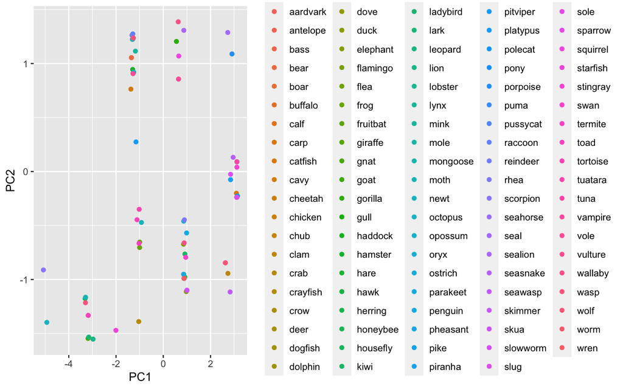

```r
zoo_pcs %>%
  ggplot(aes(x= PC1 , y=PC2 , color = animal_name)) +
  geom_point()
```

Then plot your observations in PC2 and PC3, colored by animal type.

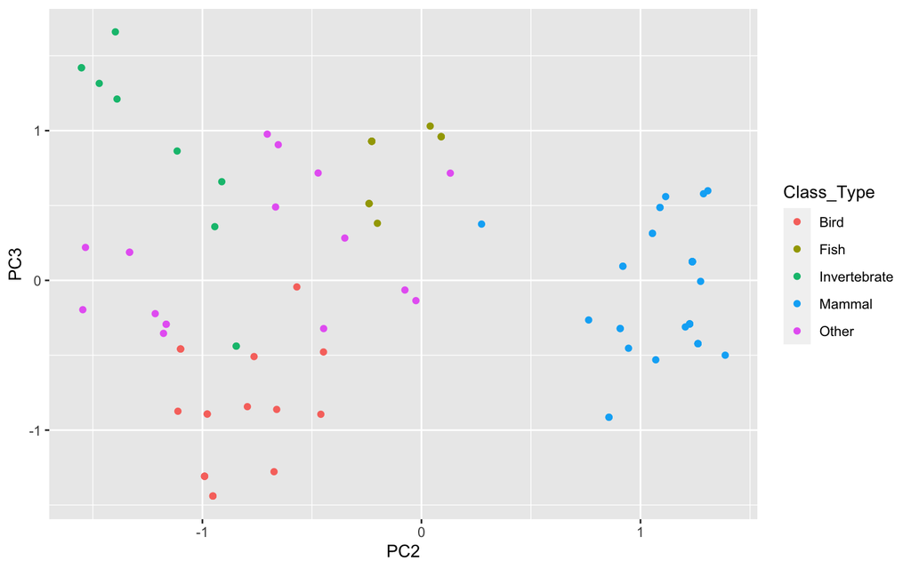

```r
zoo_pcs %>%
  ggplot(aes(x= PC2 , y=PC3 , color = Class_Type)) +
  geom_point()
```

Comment on the plots. Why are certain animal types grouped the way that they are?

- Certain animal types are grouped as such as they have different characteristics which is what determines the PC’s. For example, all the fish have fins and are thus categorized on the plot in a specific area.

## Part Two: LDA

Hint: In the following, we are trying to predict the “type” of animal, not the specific animal species. The update_role() addition to your recipe should be used so that the models don’t use the species variable in the classification process.

```r
zoo_pcs <- zoo_pcs %>%
  select(2:5)
```

### Q1: Linear

Create a Linear Discriminant that classifies animal type based on the first three PCs.

```r
lda_mod <- discrim_linear() %>%
  set_engine("MASS") %>%
  set_mode("classification")

# recipe
lda_rec <- recipe(Class_Type ~ PC1 + PC2 + PC3, data = zoo_pcs)

# workflow
lda_wflow <- workflow() %>%
  add_recipe(lda_rec) %>%
  add_model(lda_mod)

# cross validation
zoo_pcs_cv <- vfold_cv(zoo_pcs, v = 10)

# fit
lda_cv_fit <- lda_wflow %>%
  fit_resamples(resamples = zoo_pcs_cv)
```

```
## ! Fold01: internal:
##   No observations were detected in `truth` for level(s): 'Bird'
##   Computation will proceed by ignoring those levels.
```

```
## ! Fold02: internal:
##   No observations were detected in `truth` for level(s): 'Fish'
##   Computation will proceed by ignoring those levels.
```

```
## ! Fold04: internal:
##   No observations were detected in `truth` for level(s): 'Invertebrate'
##   Computation will proceed by ignoring those levels.
```

```
## ! Fold06: internal:
##   No observations were detected in `truth` for level(s): 'Fish'
##   Computation will proceed by ignoring those levels.
```

```
## ! Fold07: internal:
##   No observations were detected in `truth` for level(s): 'Fish', 'Invert...
##   Computation will proceed by ignoring those levels.
```

```
## ! Fold10: internal:
##   No observations were detected in `truth` for level(s): 'Invertebrate'
##   Computation will proceed by ignoring those levels.
```

```r
# metrics
lda_cv_fit %>% collect_metrics()
```

```
## # A tibble: 2 × 6
##   .metric  .estimator  mean     n std_err .config
##   <chr>    <chr>      <dbl> <int>   <dbl> <chr>
## 1 accuracy multiclass 0.92     10  0.02   Preprocessor1_Model1
## 2 roc_auc  hand_till  0.955    10  0.0251 Preprocessor1_Model1
```

Report appropriate metrics of your classifier.

- We have used accuracy and roc_auc as our metrics.

### Q2: Quadratic

Create a Linear Discriminant that classifies animal type based on the first three PCs.

```r
qda_mod <- discrim_regularized(frac_common_cov = 0) %>%
             set_engine('klaR') %>%
             set_mode('classification')

# recipe
qda_rec <- recipe(Class_Type ~ PC1 + PC2 + PC3, data = zoo_pcs)

# workflow
qda_wflow <- workflow() %>%
  add_recipe(qda_rec) %>%
  add_model(qda_mod)

# cross validation
zoo_pcs_cv <- vfold_cv(zoo_pcs, v = 10)

# fit
qda_cv_fit <- qda_wflow %>%
  fit_resamples(resamples = zoo_pcs_cv)
```

```
## ! Fold01: internal:
##   No observations were detected in `truth` for level(s): 'Bird', 'Other'
##   Computation will proceed by ignoring those levels.
```

```
## ! Fold03: internal:
##   No observations were detected in `truth` for level(s): 'Fish'
##   Computation will proceed by ignoring those levels.
```

```
## ! Fold04: internal:
##   No observations were detected in `truth` for level(s): 'Fish', 'Invert...
##   Computation will proceed by ignoring those levels.
```

```
## ! Fold06: internal:
##   No observations were detected in `truth` for level(s): 'Fish'
##   Computation will proceed by ignoring those levels.
```

```
## ! Fold07: internal:
##   No observations were detected in `truth` for level(s): 'Invertebrate',...
##   Computation will proceed by ignoring those levels.
```

```
## ! Fold08: internal:
##   No observations were detected in `truth` for level(s): 'Invertebrate'
##   Computation will proceed by ignoring those levels.
```

```
## ! Fold09: internal:
##   No observations were detected in `truth` for level(s): 'Invertebrate',...
##   Computation will proceed by ignoring those levels.
```

```
## ! Fold10: internal:
##   No observations were detected in `truth` for level(s): 'Invertebrate'
##   Computation will proceed by ignoring those levels.
```

```r
# metrics
qda_cv_fit %>% collect_metrics()
```

```
## # A tibble: 2 × 6
##   .metric  .estimator  mean     n std_err .config
##   <chr>    <chr>      <dbl> <int>   <dbl> <chr>
## 1 accuracy multiclass  0.98    10  0.0133 Preprocessor1_Model1
## 2 roc_auc  hand_till   1       10  0      Preprocessor1_Model1
```

Report appropriate metrics of your classifier.

- We have used accuracy and roc_auc as our metrics.

### Q3: Interpretation

Which classifier did better?

- QDA performed better than LDA

Intuitively, why do you think that is?

- This is because QDA fits the data better and provides more flexibility when splitting categories into different areas. Since there are a lot of classifications required in different areas of the plot using a QDA should be better.

## Part Three: SVM

```r
roc_vals <- metric_set(roc_auc)
ctrl <- control_grid(verbose = FALSE, save_pred = TRUE)
```

### Q1: Linear

Create a Support Vector Classifier (aka, an SVM with no kernel) that classifies animal type based on the first three PCs. You should tune the cost parameter.

```r
svm_specs <- svm_linear(cost = tune()) %>%
  set_mode("classification") %>%
  set_engine("kernlab")

svm_rec <- recipe(Class_Type ~ PC1 + PC2 + PC3, data = zoo_pcs)

svm_grid <- expand.grid(cost = c(0.25, 0.5, 0.75, 1, 1.25, 1.5, 1.75, 2))

 svm_wflow <- workflow() %>%
   add_model(svm_specs) %>%
   add_recipe(svm_rec)

 svm_results <-  svm_wflow %>%
  tune_grid(resamples = zoo_pcs_cv,
            grid = svm_grid)
```

```
## ! Fold01: internal:
##   No observations were detected in `truth` for level(s): 'Bird', 'Other'
##   Computation will proceed by ignoring those levels.
```

```
## ! Fold03: internal:
##   No observations were detected in `truth` for level(s): 'Fish'
##   Computation will proceed by ignoring those levels.
```

```
## ! Fold04: internal:
##   No observations were detected in `truth` for level(s): 'Fish', 'Invert...
##   Computation will proceed by ignoring those levels.
```

```
## ! Fold06: internal:
##   No observations were detected in `truth` for level(s): 'Fish'
##   Computation will proceed by ignoring those levels.
```

```
## ! Fold07: internal:
##   No observations were detected in `truth` for level(s): 'Invertebrate',...
##   Computation will proceed by ignoring those levels.
```

```
## ! Fold08: internal:
##   No observations were detected in `truth` for level(s): 'Invertebrate'
##   Computation will proceed by ignoring those levels.
```

```
## ! Fold09: internal:
##   No observations were detected in `truth` for level(s): 'Invertebrate',...
##   Computation will proceed by ignoring those levels.
```

```
## ! Fold10: internal:
##   No observations were detected in `truth` for level(s): 'Invertebrate'
##   Computation will proceed by ignoring those levels.
```

```r
svm_results %>%
  collect_metrics() %>%
  arrange(desc(mean))
```

```
## # A tibble: 16 × 7
##     cost .metric  .estimator  mean     n std_err .config
##    <dbl> <chr>    <chr>      <dbl> <int>   <dbl> <chr>
##  1  0.25 roc_auc  hand_till  0.955    10  0.0186 Preprocessor1_Model1
##  2  0.75 roc_auc  hand_till  0.929    10  0.0217 Preprocessor1_Model3
##  3  2    roc_auc  hand_till  0.923    10  0.0217 Preprocessor1_Model8
##  4  0.5  roc_auc  hand_till  0.919    10  0.0236 Preprocessor1_Model2
##  5  1    roc_auc  hand_till  0.916    10  0.0222 Preprocessor1_Model4
##  6  1.25 roc_auc  hand_till  0.914    10  0.0233 Preprocessor1_Model5
##  7  1.75 roc_auc  hand_till  0.913    10  0.0240 Preprocessor1_Model7
##  8  1.5  roc_auc  hand_till  0.911    10  0.0243 Preprocessor1_Model6
##  9  1    accuracy multiclass 0.91     10  0.0180 Preprocessor1_Model4
## 10  1.5  accuracy multiclass 0.91     10  0.0180 Preprocessor1_Model6
## 11  1.75 accuracy multiclass 0.91     10  0.0180 Preprocessor1_Model7
## 12  2    accuracy multiclass 0.91     10  0.0180 Preprocessor1_Model8
## 13  0.75 accuracy multiclass 0.9      10  0.0211 Preprocessor1_Model3
## 14  1.25 accuracy multiclass 0.89     10  0.0180 Preprocessor1_Model5
## 15  0.5  accuracy multiclass 0.88     10  0.0249 Preprocessor1_Model2
## 16  0.25 accuracy multiclass 0.84     10  0.0340 Preprocessor1_Model1
```

Report appropriate metrics of your classifier.

```r
svm_specs1 <- svm_linear(cost = 0.25) %>%
  set_mode("classification") %>%
  set_engine("kernlab")

svm_wflow1 <- workflow() %>%
  add_model(svm_specs1) %>%
  add_recipe(svm_rec)

my_svm1 <- svm_wflow1 %>%
  fit_resamples(zoo_pcs_cv)
```

```
## ! Fold01: internal:
##   No observations were detected in `truth` for level(s): 'Bird', 'Other'
##   Computation will proceed by ignoring those levels.
```

```
## ! Fold03: internal:
##   No observations were detected in `truth` for level(s): 'Fish'
##   Computation will proceed by ignoring those levels.
```

```
## ! Fold04: internal:
##   No observations were detected in `truth` for level(s): 'Fish', 'Invert...
##   Computation will proceed by ignoring those levels.
```

```
## ! Fold06: internal:
##   No observations were detected in `truth` for level(s): 'Fish'
##   Computation will proceed by ignoring those levels.
```

```
## ! Fold07: internal:
##   No observations were detected in `truth` for level(s): 'Invertebrate',...
##   Computation will proceed by ignoring those levels.
```

```
## ! Fold08: internal:
##   No observations were detected in `truth` for level(s): 'Invertebrate'
##   Computation will proceed by ignoring those levels.
```

```
## ! Fold09: internal:
##   No observations were detected in `truth` for level(s): 'Invertebrate',...
##   Computation will proceed by ignoring those levels.
```

```
## ! Fold10: internal:
##   No observations were detected in `truth` for level(s): 'Invertebrate'
##   Computation will proceed by ignoring those levels.
```

```r
my_svm1 %>% collect_metrics()
```

```
## # A tibble: 2 × 6
##   .metric  .estimator  mean     n std_err .config
##   <chr>    <chr>      <dbl> <int>   <dbl> <chr>
## 1 accuracy multiclass 0.84     10  0.0340 Preprocessor1_Model1
## 2 roc_auc  hand_till  0.940    10  0.0262 Preprocessor1_Model1
```

### Q2: SVM

Repeat Q1, this time for a full Support Vector Machine with a polynomial kernel.

(You may use the same cost you chose in Q1, but you should tune the degree.)

```r
svm_specs2 <- svm_poly(cost = 0.25, degree = tune()) %>%
  set_mode("classification") %>%
  set_engine("kernlab")

svm_degree_grid <- expand.grid(degree = c(1, 2, 3, 4))

svm_wflow2 <- workflow() %>%
  add_model(svm_specs2) %>%
  add_recipe(svm_rec)

svm_results <-  svm_wflow2 %>%
  tune_grid(resamples = zoo_pcs_cv,
            grid = svm_degree_grid)
```

```
## ! Fold01: internal:
##   No observations were detected in `truth` for level(s): 'Bird', 'Other'
##   Computation will proceed by ignoring those levels.
```

```
## ! Fold03: internal:
##   No observations were detected in `truth` for level(s): 'Fish'
##   Computation will proceed by ignoring those levels.
```

```
## ! Fold04: internal:
##   No observations were detected in `truth` for level(s): 'Fish', 'Invert...
##   Computation will proceed by ignoring those levels.
```

```
## ! Fold06: internal:
##   No observations were detected in `truth` for level(s): 'Fish'
##   Computation will proceed by ignoring those levels.
```

```
## ! Fold07: internal:
##   No observations were detected in `truth` for level(s): 'Invertebrate',...
##   Computation will proceed by ignoring those levels.
```

```
## ! Fold08: internal:
##   No observations were detected in `truth` for level(s): 'Invertebrate'
##   Computation will proceed by ignoring those levels.
```

```
## ! Fold09: internal:
##   No observations were detected in `truth` for level(s): 'Invertebrate',...
##   Computation will proceed by ignoring those levels.
```

```
## ! Fold10: internal:
##   No observations were detected in `truth` for level(s): 'Invertebrate'
##   Computation will proceed by ignoring those levels.
```

```r
svm_results %>%
  collect_metrics() %>%
  arrange(desc(mean))
```

```
## # A tibble: 8 × 7
##   degree .metric  .estimator  mean     n std_err .config
##    <dbl> <chr>    <chr>      <dbl> <int>   <dbl> <chr>
## 1      2 roc_auc  hand_till  0.987    10 0.00972 Preprocessor1_Model2
## 2      4 roc_auc  hand_till  0.970    10 0.0167  Preprocessor1_Model4
## 3      3 roc_auc  hand_till  0.968    10 0.0176  Preprocessor1_Model3
## 4      3 accuracy multiclass 0.96     10 0.0163  Preprocessor1_Model3
## 5      4 accuracy multiclass 0.96     10 0.0163  Preprocessor1_Model4
## 6      2 accuracy multiclass 0.95     10 0.0167  Preprocessor1_Model2
## 7      1 roc_auc  hand_till  0.934    10 0.0254  Preprocessor1_Model1
## 8      1 accuracy multiclass 0.84     10 0.0340  Preprocessor1_Model1
```

```r
svm_specs <- svm_poly(cost = 0.25, degree = 2) %>%
  set_mode("classification") %>%
  set_engine("kernlab")

svm_wflow <- workflow() %>%
  add_model(svm_specs) %>%
  add_recipe(svm_rec)

my_svm <- svm_wflow %>%
  fit_resamples(zoo_pcs_cv)
```

```
## ! Fold01: internal:
##   No observations were detected in `truth` for level(s): 'Bird', 'Other'
##   Computation will proceed by ignoring those levels.
```

```
## ! Fold03: internal:
##   No observations were detected in `truth` for level(s): 'Fish'
##   Computation will proceed by ignoring those levels.
```

```
## ! Fold04: internal:
##   No observations were detected in `truth` for level(s): 'Fish', 'Invert...
##   Computation will proceed by ignoring those levels.
```

```
## ! Fold06: internal:
##   No observations were detected in `truth` for level(s): 'Fish'
##   Computation will proceed by ignoring those levels.
```

```
## ! Fold07: internal:
##   No observations were detected in `truth` for level(s): 'Invertebrate',...
##   Computation will proceed by ignoring those levels.
```

```
## ! Fold08: internal:
##   No observations were detected in `truth` for level(s): 'Invertebrate'
##   Computation will proceed by ignoring those levels.
```

```
## ! Fold09: internal:
##   No observations were detected in `truth` for level(s): 'Invertebrate',...
##   Computation will proceed by ignoring those levels.
```

```
## ! Fold10: internal:
##   No observations were detected in `truth` for level(s): 'Invertebrate'
##   Computation will proceed by ignoring those levels.
```

```r
my_svm %>% collect_metrics()
```

```
## # A tibble: 2 × 6
##   .metric  .estimator  mean     n std_err .config
##   <chr>    <chr>      <dbl> <int>   <dbl> <chr>
## 1 accuracy multiclass 0.95     10 0.0167  Preprocessor1_Model1
## 2 roc_auc  hand_till  0.990    10 0.00920 Preprocessor1_Model1
```

### Q3: Interpretation

Explain intuitively why your polynomial SVM had better accuracy than your ordinary linear one.

- Polynomial SVM had better accuracy than your ordinary linear one because polynomial SVM allows more flexibility and fits the data better

## Part Four: Prediction

How would your models classify a human being?

Alter the code below to make a dataset with one observation, representing a human. Use your best LDA or QDA model, and your best SVC or SVM model, to predict the species of a human.

Instead of finding only the first predicted type, show the probabilities of each category. (Recall: the type = “prob” option in the predict() function)

(Hint: the catsize variable means “bigger than a cat”)

```r
human <- data.frame(
  animal_name = "human",
  hair = 1,
  feathers = 0,
  eggs = 0,
  milk = 1,
  airborne = 0,
  aquatic = 0,
  predator = 1,
  toothed = 1,
  backbone = 1,
  breathes = 1,
  venomous = 0,
  fins = 0,
  legs = 2,
  tail = 0,
  domestic = 0,
  catsize = 1
)
```

### QDA

```r
human_rec <- recipe(Class_Type ~ hair + feathers + eggs + milk + airborne + aquatic + predator + toothed + backbone + breathes + venomous + fins + legs + tail + domestic + catsize, data = zoo) %>%
  step_pca(all_numeric(), threshold = 0.9,
           options = c(center =TRUE))

qda_wflow2 <- workflow() %>%
  add_recipe(human_rec) %>%
  add_model(qda_mod)

qda_fit <- qda_wflow2 %>%
  fit(zoo)

predict(qda_fit, new_data = human, type = "prob")
```

```
## # A tibble: 1 × 5
##   .pred_Bird .pred_Fish .pred_Invertebrate .pred_Mammal .pred_Other
##        <dbl>      <dbl>              <dbl>        <dbl>       <dbl>
## 1   4.43e-50          0      0.00000000124         1.00    6.42e-12
```

### SVM

```r
svm_specs <- svm_poly(cost = 0.25, degree = 2) %>%
  set_mode("classification") %>%
  set_engine("kernlab")

svm_wflow <- workflow() %>%
  add_recipe(human_rec) %>%
  add_model(svm_specs)

my_svm <- svm_wflow %>%
  fit(zoo)

predict(my_svm, new_data = human, type = "prob")
```

```
## # A tibble: 1 × 5
##   .pred_Bird .pred_Fish .pred_Invertebrate .pred_Mammal .pred_Other
##        <dbl>      <dbl>              <dbl>        <dbl>       <dbl>
## 1     0.0988      0.104             0.0752        0.584       0.138
```

- Both models predict humans as mammals.